# bayes_spectra

*Parameter recovery from simulated data*

To ensure that the models could recover known parameter values, we simulated ten data sets from a bounded power law:

$$x_i = (\text{u}_ix_{max}^{(\lambda+1)}
+ (1-\text{u}_i) x_{min}^{(\lambda+1)} ) ^ {\frac{(1}{(\lambda+1)}}$$

where $x_i$ is the individual body size from the $i$th simulation, $u_i$ is a unique draw from a $Uniform(0,1)$ distribution, and all other variables are the same as defined above. We set $x_{min}$ =1 and $x_{max}$ = 1000, and simulated $i$ = 1000 values from each of 10 $\lambda$’s ranging from -2.2 to -1.2. To generate $counts$, we rounded each simulated value to the nearest 0.001 and then tallied them.

We estimated the ten $\lambda$ values in two ways. First, we fit a separate intercept-only model to each of the ten data sets. Second, we fit a varying intercepts model (Gelman et al. 2014). The structure of this model is $b = \alpha + \alpha_{[group]}$ where each group represents and offset from the mean value of lambda.

Finally, we simulated data for a regression model with a single continuous predictor and a varying intercept: $lambda = \alpha + \beta x + \alpha_{[group]}$, where $\alpha$ = -1.5, $\beta$ = -0.1, and $\sigma_{group}$ was 0.3 for n = 3 groups. The predictor $x$ was continuous with 3 values (-2, 0, 2) and two replicates per value per group for n = 18 $\lambda$’s. After solving for $\lambda$ from these known parameter values, we simulated 300 individuals from each $\lambda$ using the procedure above, with $x_{min}$ = 1 and $x_{max}$ = 100. We fit this model 20 times to measure variation in parameter recovery among model runs.

*Sample Size*

To examine sensitivity to sample size (number of individual body sizes), we simulated data sets with using three $\lambda$ values (-2, -1.6, -1.2). For each $\lambda$, we varied the number of individuals across a $2^n$ sequence with $n$ ranging from 1 to 11, resulting in 11 data sets ranging from 2 to 2048 individuals. Each density was replicated 10 times. We then plotted the modeled $\lambda$ values as a function of sample size.

*Case Studies*

We fit each of the above models in rstan (Stan Development Team 2022) using 2 chains each with 1000 iterations. All models converged with $r_{hat}$’s <1.01. If a known parameter value fell inside the 95% Credible Intervals, we considered parameter recover successful. For the replicated regression model, we also tallied the number of times that the known value fell outside of the highest posterior density interval (HPI; out 20 runs).

**Results**

*Parameter Recovery*

For models fit to simulated individual data set, all credible intervals included the true value of $\lambda$ and posterior medians were no more than 0.05 units away from the true value (Table 1). Similarly, when the same data set was fit using a varying intercepts model, the posterior median intercept $\alpha$ and group standard deviation $\sigma_{group}$ were nearly identical to the true values (Table 1).

Table X. Parameter recovery.

| Model | Parameter | True Value | q2.5 | q50 | q97.5 |
| --- | --- | --- | --- | --- | --- |
| Separate Models | λ | -2.20 | -2.22 | -2.15 | -2.09 |
| Separate Models | λ | -2.09 | -2.13 | -2.06 | -2.00 |
| Separate Models | λ | -1.98 | -2.05 | -1.99 | -1.92 |
| Separate Models | λ | -1.87 | -1.91 | -1.85 | -1.80 |
| Separate Models | λ | -1.76 | -1.83 | -1.78 | -1.72 |
| Separate Models | λ | -1.64 | -1.70 | -1.66 | -1.61 |
| Separate Models | λ | -1.53 | -1.59 | -1.54 | -1.50 |
| Separate Models | λ | -1.42 | -1.48 | -1.44 | -1.40 |
| Separate Models | λ | -1.31 | -1.31 | -1.28 | -1.24 |
| Separate Models | λ | -1.20 | -1.26 | -1.23 | -1.20 |
| Single Model with Varying Intercepts | α | -1.70 | -1.96 | -1.71 | -1.50 |
| Single Model with Varying Intercepts | σ_[group] | 0.34 | 0.23 | 0.36 | 0.58 |

Using the varying intercept model to estimate group specific means yielded similar results as using separate models per group (Figure 1), demonstrating that a single model can be used to estimate multiple size spectra simultaneously.

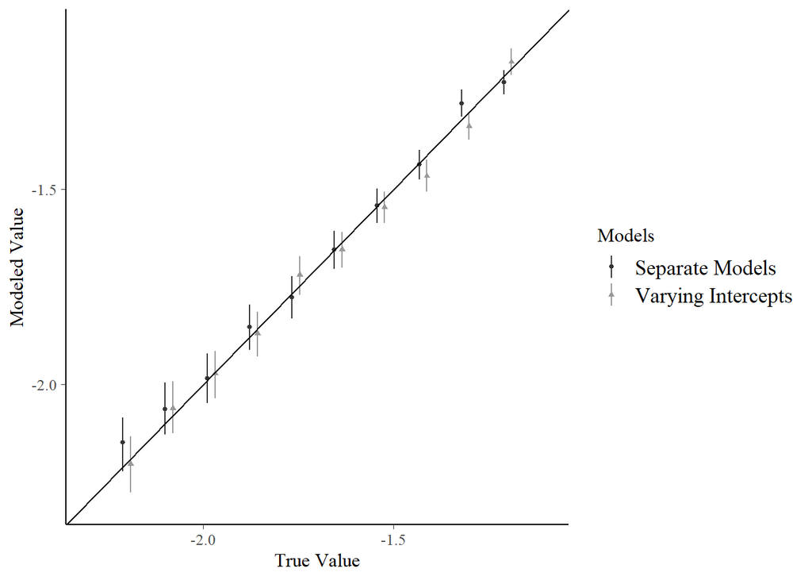

Modeled estimates (median +/- 95% Credible Intervals of λ using either 10 separate models or a single model with ten varying intercepts.

We also successfully recovered regression parameters (intercept $\alpha$ and slope $\beta$) along with the group-level sd ($\sigma_{group}$) (Figure 2). Fitting this model 20 times indicated reliable fit. For example, out of 60 comparison (3 parameters x 20 replicates) the true value fell outside of the 95% HDI only once (Figure 2). Averaging the deviations (posterior median minus the true value) among the replicates indicated no bias in the modeled estimates (mean bias +/- sd: $\alpha$ = 0 +/- 0.05, $\beta$ = 0 +/- 0.008, $\sigma_{group}$ = 0.03 +/- 0.06).

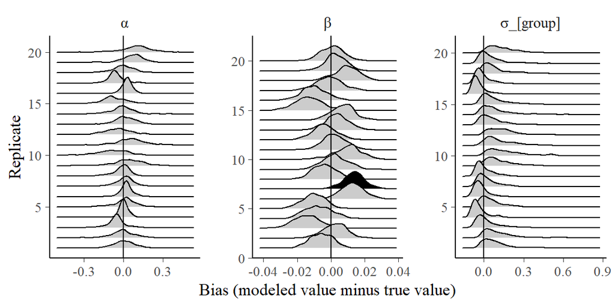

Posterior distributions of n = 20 modeled estimates of alpha, beta, and sigma_group for a linear regression estimating the size sepctrum exponent as a function of a continuous predictor. All data were simulated. Gray densities indicate that the HPI contains the true value, while black densities indicat the opposite. The vertical lines indicate true values.

*Sample Size*

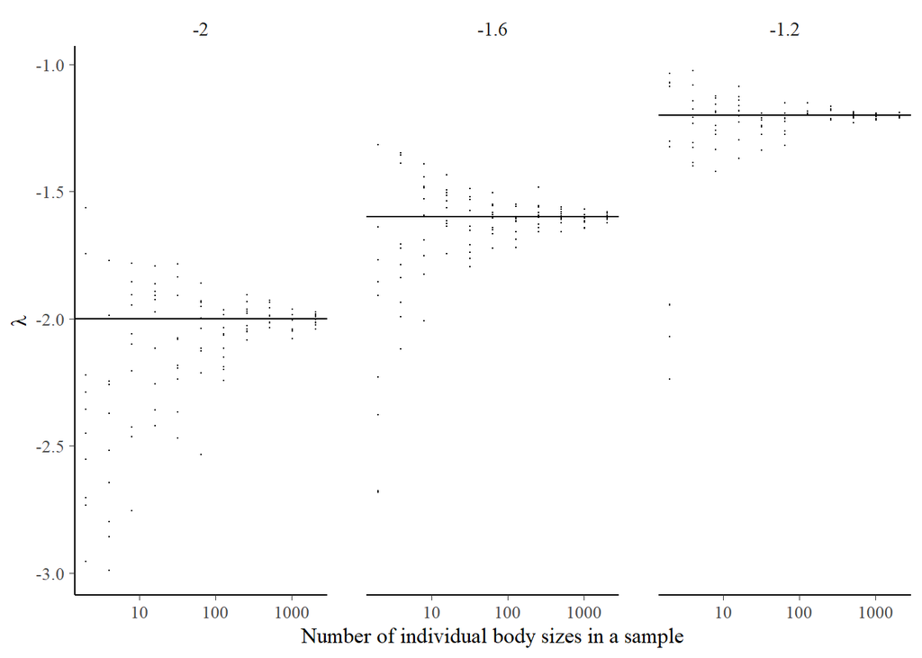

Estimates of λ across 11 different sample sizes (ranging from 2 to 2048 individuals) and three different true λ’s (-2, -1.6, -1.2). Ten separate models were fit for each of the 11 sample sizes. The horizontal lines show the true value of λ

*Case Study*

Using IBTS data with the Bayesian hierarchical regression, we found a negative trend over time. The ISD exponent of IBTS trawl data declined by ~0.001 units per year, but with a 95% CrI ranging from -0.005 to 0.002. These values were nearly identical to those reported by Edwards et al. (2020) using a two-step approach (Table 3).

Table X. Slope values from a regression testing the relationship between the ISD exponent and year for IBTS trawl data (Edwards et al. 2020). The values are derived using the Bayesian hierarchical model presentd here or from the maximum likelihood approach described in Edwards et al. 2020).

| Model | Mean | q2.5 | q97.5 |
| --- | --- | --- | --- |
| Bayesian - one step | -0.001 | -0.005 | 0.002 |
| MLE - two steps | -0.001 | -0.005 | 0.003 |

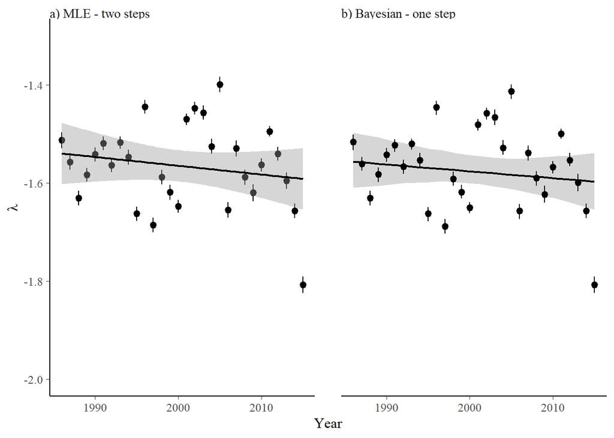

Regression results from a) Edwards et al. (2020) using maximum likelihood and linear regression (two steps) and b) from the Bayesian model with a paretocounts lpdf (one step). In a) the points represent maximume likelihood estimates calculated separately for each year. In b) they represent hierarchical varying intercepts calculated from the model.

**Discussion**

The most important result of this work is the ability to analyze ISD exponents using fixed and random predictors using a hierarchical modelling framework. This allows ecologists to test theoretical and empirical hypotheses about size spectra in a single analytical framework. This is critical to examine how communities vary across space, time, and in response to environmental gradients.

**Supplementary Information**

1. Run model on simulated data and ensure that parameters are recovered (they are, just need to add)
2. Run model in individual sites and compare with results from sizeSpectra package
3. Derive posterior predictive equation. The current method works, but may not capture the influence of counts (no_m2) correctly. Need help on this.